# Homework 1: Autoregressive Models (Deadline: 12/03/2026)

In this homework, you will implement several autoregressive models on the task of image generation.

Autoregressive models are powerful generative models that remain among the state-of-the-art approaches for likelihood-based image modeling. They also form the foundation of modern large-scale language models such as GPT-4.

Recall that an autoregressive model structures the generation problem in the form:

$p_{\theta}(x) = \prod_{i=1}^{d} p_{\theta}(x_{i} | x_{1:i-1})$

In both autoregressive models you will implement in this homework, you will generate **one pixel at a time**. Hence, the conditional probabilities in the above formula look at all previously generated pixels when predicting the next pixel.

# First Things First: Academic Integrity for Homework1

In our Deep Unsupervised Learning course, all work on assignments must be done individually unless stated otherwise. You can make discussions in an "abstract" way. However, it's crucial to distinguish between constructive discussions and the inappropriate use of resources: turning in someone else’s or your friend's work, in whole or in part, as your own will be considered as a violation of academic integrity. Please note that the former condition also holds for the material found on the web as everything on the web has been written by someone else. In short, using code from your peers or from any online sources as your own work **will not be tolerated**.

**You can use LLM's to help you understand the content, but you are strictly prohibited from making them answer the questions in your stead. Doing so will be considered as cheating, and disciplinary action will be taken.**

# Getting Started

## Overview

This semester, all homeworks will be conducted through Google Colab notebooks. All code for the homework assignment will be written and run in this notebook. Running in Colab will automatically provide a GPU, but you may also run this notebook locally by following [these instructions](https://research.google.com/colaboratory/local-runtimes.html) if you wish to use your own GPU.

## **Submission**

Instead of submitting an .ipynb copy of this notebook, **you should export this notebook as a PDF** and **submit the PDF** to LearnHub, while making sure no parts of your code/answers or results are omitted. We will only accept the PDF submissions.

If you are using Colab, to export the notebook as a PDF, go to **File → Print**, then in the browser print window select **Save as PDF**. Please make sure to double-check that all outputs are visible and correctly rendered in your notebook before exporting.

**Note**: You can export the PDF however you like, or use whatever tool for notebooks such as Jupyter Notebook, as long as you make sure that no content of your doing was omitted.

Please **do not submit zip files**.

## Using Colab

On the left-hand side, you can click the different icons to see a Table of Contents of the assignment, as well as local files accessible through the notebook.

Make sure to go to **Runtime -> Change runtime type** and select **GPU** as the hardware accelerator. This allows you to use a GPU. Run the cells below to get started on the assignment. Note that a session is open for a maximum of 12 hours, and using too much GPU compute may result in restricted access for a short period of time. Please start the homework early so you have ample time to work.

**If you loaded this notebook from clicking "Open in Colab" from github, you will need to save it to your own Google Drive to keep your work.**

## General Tips

We will use the MNIST dataset in our implementations. In Part 1, the expected sample quality is given for your reference at the end of the question.

After each part, there will be a written question that you will need to answer about that part. These questions are given under the Inline Question title. You just need to write your answers below those questions.

Feel free to print whatever output (e.g. debugging code, training code, etc) you want. Your graded submission will be the pdf you submit together with a copy of your notebook.

You will be implementing the code using PyTorch. Some parts of the code such as function headers are already provided to you, you will need to fill out the parts with "YOUR CODE HERE" . Feel free to create more cells and more functions or modify the existing ones if you wish.

Run the cells below to download and load up the starter code.

```python
!if [ -d deepul ]; then rm -Rf deepul; fi
!git clone https://github.com/emrecanacikgoz/deepul.git
!unzip -qq deepul/homeworks/hw1/data/hw1_data.zip -d deepul/homeworks/hw1/data/
!mv deepul/homeworks/hw1/data/hw1_data/* deepul/homeworks/hw1/data/
!pip install ./deepul
```

```
Cloning into 'deepul'...
remote: Enumerating objects: 256, done.
remote: Counting objects: 100% (18/18), done.
remote: Compressing objects: 100% (14/14), done.
remote: Total 256 (delta 3), reused 14 (delta 3), pack-reused 238 (from 1)
Receiving objects: 100% (256/256), 88.75 MiB | 7.50 MiB/s, done.
Resolving deltas: 100% (114/114), done.
Processing ./deepul
  Preparing metadata (setup.py) ... done
```

```python
from deepul.hw1_helper import *
```

# Part 1: Gated PixelCNN

In the first part, you train one of the PixelCNN variants, namely Gated PixelCNN on the shapes dataset and MNIST. For reference, you may find the original PixelCNN paper [here](https://arxiv.org/pdf/1601.06759v3).

We suggest you to familiarize yourself with the paper before attempting the implementation.

```python
import torch
import torch.nn as nn
import torch.nn.functional as F
from torchvision import datasets, transforms
import os
import sys
from torch import optim
from torch.utils import data
import torchvision
import numpy as np
import matplotlib.pyplot as plt
%matplotlib inline
```

## Gated PixelCNN on MNIST

```
Dataset MNIST
    Number of datapoints: 60000
    Root location: /content/data
    Split: Train
    StandardTransform
Transform: ToTensor()
```

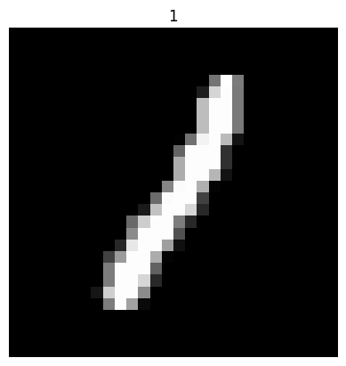

```python
dataset_path = '/content/data'
transform = transforms.ToTensor()
train_data = datasets.MNIST(root=dataset_path,
                            train=True,
                            download=True,
                            transform=transform)
test_data = datasets.MNIST(root=dataset_path,
                            train=False,
                            download=True,
                            transform=transform)
print(train_data)

plt.imshow(train_data.data[447], cmap='gray')
plt.title('%i' % train_data.targets[447])
plt.axis('off')
plt.show()
```

### Your Solution

As you have seen in the lecture, PixelCNN utilizes masked convolutions to ensure the autoregressive property is satisfied. First start by implementing a masked convolutional layer. Remember that there are two different types of layers, type A and type B, depending on the masking you are using.

A class header is provided to you in the cell below, which extends the `nn.Conv2d` class. You may wish to implement your layer that extends the `nn.Module` class instead.

```python
class MaskedConv2d(nn.Conv2d):
  def __init__(self, mask_type, *args, **kwargs):
    super().__init__(*args, **kwargs)
    assert mask_type in ('A', 'B')
    self.register_buffer('mask', torch.ones_like(self.weight))
    _, _, h, w = self.weight.shape
    self.mask[:, :, h // 2 + 1:, :] = 0
    self.mask[:, :, h // 2, w // 2 + (1 if mask_type == 'B' else 0):] = 0

  def forward(self, x):
    return F.conv2d(x, self.weight * self.mask, self.bias, self.stride, self.padding, self.dilation, self.groups)
```

Next, you will implement the gated version of the PixelCNN, which solves the blind spot problem of PixelCNN. Unlike the original PixelCNN, Gated PixelCNN introduces distinct horizontal and vertical stacks to improve information flow. Please take a look at [the paper](https://arxiv.org/pdf/1606.05328.pdf) for the detailed implementation.

First, we will start by implementing a GatedConv2d layer, following Figure 2 of the paper:

[figure not shown]

Please take a look at this figure and read the Gated Convolutional Layers part of the paper carefully to implement the following function. This layer should include 4 convolutions with different kernel sizes, as shown in the figure. Again, a header is provided to you, but you may wish to write your own class or your own functions:

```python
class GatedConv2d(nn.Module):
  def __init__(self, mask_type, in_channels, out_channels, kernel_size=7, padding=3):
    super().__init__()
    assert mask_type in ('A', 'B')
    self.mask_type = mask_type
    self.padding = padding
    k = kernel_size

    self.v_conv = nn.Conv2d(in_channels, 2 * out_channels, kernel_size=(k // 2 + 1, k), padding=0)
    self.v_to_h = nn.Conv2d(2 * out_channels, 2 * out_channels, kernel_size=1)

    if mask_type == 'A':
      self.h_conv = nn.Conv2d(in_channels, 2 * out_channels, kernel_size=(1, k // 2), padding=0)
    else:
      self.h_conv = nn.Conv2d(in_channels, 2 * out_channels, kernel_size=(1, k // 2 + 1), padding=0)

    self.h_res = nn.Conv2d(out_channels, out_channels, kernel_size=1)

  def forward(self, x):
    v_input, h_input = x.chunk(2, dim=1)
    pad = self.padding

    v_padded = F.pad(v_input, (pad, pad, pad + 1, 0))
    v_out = self.v_conv(v_padded)
    v_out = v_out[:, :, :v_input.shape[2], :]

    h_padded = F.pad(h_input, (pad, 0, 0, 0))
    h_out = self.h_conv(h_padded)
    if self.mask_type == 'A':
      h_out = h_out[:, :, :, :h_input.shape[3]]

    h_out = h_out + self.v_to_h(v_out)

    v_tanh, v_sigmoid = v_out.chunk(2, dim=1)
    v_out = torch.tanh(v_tanh) * torch.sigmoid(v_sigmoid)

    h_tanh, h_sigmoid = h_out.chunk(2, dim=1)
    h_out = torch.tanh(h_tanh) * torch.sigmoid(h_sigmoid)

    h_out = self.h_res(h_out)
    if self.mask_type == 'B':
      h_out = h_out + h_input

    return torch.cat([v_out, h_out], dim=1)
```

Now, you can use this layer inside your GatedPixelCNN model. Here is a pseudocode for the reference implementation:

```
class GatedPixelCNN
  MaskedConv2d(mask_type='A', in_channels = 1, out_channels = 120, kernel_size = 7, padding = 3)
  BatchNorm(num_features=2*120)
  ReLU()

  for _ in range(3):
    GatedConv2d(mask_type='B', in_channels = 120, out_channels = 120, kernel_size = 7, padding = 3)
    BatchNorm(num_features=2*120)
    ReLU()

  MaskedConv2d(mask_type='B', in_channels = 120, out_channels = 256, kernel_size = 7, padding = 3)
```

```python
class GatedPixelCNN(nn.Module):
  def __init__(self, num_layers=5, num_channels=120, kernel_size=7):
    super().__init__()
    padding = kernel_size // 2
    self.initial_conv = MaskedConv2d('A', 1, num_channels, kernel_size, 1, padding)
    self.initial_bn = nn.BatchNorm2d(2 * num_channels)

    self.gated_layers = nn.ModuleList()
    self.bns = nn.ModuleList()
    for _ in range(num_layers - 2):
      self.gated_layers.append(GatedConv2d('B', num_channels, num_channels, kernel_size, padding))
      self.bns.append(nn.BatchNorm2d(2 * num_channels))

    self.final_conv = MaskedConv2d('B', num_channels, 256, kernel_size, 1, padding)

  def forward(self, x):
    x = self.initial_conv(x)
    x = torch.cat([x, x], dim=1)
    x = F.relu(self.initial_bn(x))

    for gated, bn in zip(self.gated_layers, self.bns):
      x = gated(x)
      x = F.relu(bn(x))

    x = x.chunk(2, dim=1)[1]
    x = self.final_conv(x)
    return x
```

Now you are ready to train your model. Fill in the function `q2_c` below to train the model and return the correct deliverables. In this function, you will initialize your model and train this model. The reference implementation uses `batch_size = 128`, `num_epocs = 3`, `optimizer = Adam`, `lr = 1e-3` as hyperparameters. Use Cross Entropy Loss to train this model.

**You will provide the following deliverables:**

- **A list of training losses evaluated at every minibatch. (Create an empty list before training, append the loss after every minibatch and return the final list).**
- **A list of test losses evaluated once at initialization and after each epoch. (Create an empty list. Evaluate on the test set before training and append it to this list. After every epoch, evaluate on the test set again and append to the list. Return the final list).**
- **25 samples drawn from your trained model. (The sampling function is already provided to you. Just call this function after training and return the samples).**

Here is a pseudocode for the reference implementation. Once again, you may wish to implement a generic training function (`train_model`) that takes your model and dataloaders and returns the training losses, or use your implementations from previous parts:

```
function q2_c():
  batch_size = 128
  num_epochs = 3
  train_loader = data.DataLoader(train_data, ...)
  test_loader = data.DataLoader(test_data, ...)
  device = 'cuda:0' or 'cpu'
  model = GatedPixelCNN().to(device)
  train_losses, test_losses = train_model(model, train_loader, test_loader, ...)

  samples = sample_gated(model)
  return train_losses, test_losses, samples
```

```python
# Execute this cell, nothing to implement here
def sample_gated(model):
  """
  model: GatedPixelCNN model trained on MNIST

  Returns
  - sample: A tensor containing the samples generated by the model
  """

  no_images = 25
  images_channels = 1
  images_size = 28
  sample = torch.Tensor(no_images, images_channels, images_size, images_size).cuda()
  sample.fill_(0)

  for i in range(images_size):
    for j in range(images_size):
      out = model(sample)
      probs = F.softmax(out[:,:,i,j], dim=-1).data
      sample[:,:,i,j] = torch.multinomial(probs, 1).float() / 255.0
  return sample.cpu()
```

```python
def q2_c(train_data, test_data):
  batch_size = 128
  num_epochs = 3
  lr = 1e-3
  device = torch.device('cuda' if torch.cuda.is_available() else 'cpu')

  train_loader = data.DataLoader(train_data, batch_size=batch_size, shuffle=True)
  test_loader = data.DataLoader(test_data, batch_size=batch_size, shuffle=False)

  model = GatedPixelCNN().to(device)
  optimizer = optim.Adam(model.parameters(), lr=lr)
  criterion = nn.CrossEntropyLoss()

  train_losses = []
  test_losses = []

  def eval_test():
    model.eval()
    total_loss = 0
    n = 0
    with torch.no_grad():
      for images, _ in test_loader:
        images = images.to(device)
        targets = (images[:, 0] * 255).long()
        output = model(images)
        loss = criterion(output, targets)
        total_loss += loss.item() * images.size(0)
        n += images.size(0)
    return total_loss / n

  test_losses.append(eval_test())
  print(f'Init test loss: {test_losses[-1]:.4f}')

  for epoch in range(num_epochs):
    model.train()
    for images, _ in train_loader:
      images = images.to(device)
      targets = (images[:, 0] * 255).long()
      output = model(images)
      loss = criterion(output, targets)
      optimizer.zero_grad()
      loss.backward()
      optimizer.step()
      train_losses.append(loss.item())

    test_losses.append(eval_test())
    print(f'Epoch {epoch+1}/{num_epochs}, test loss: {test_losses[-1]:.4f}')

  samples = sample_gated(model)
  return train_losses, test_losses, samples
```

### Results

Once you've implemented `q2_c`, execute the cell below to visualize and save your results

[output not shown]

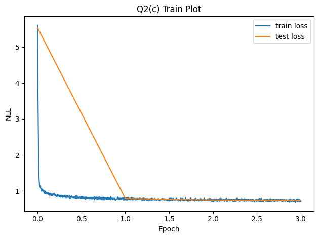

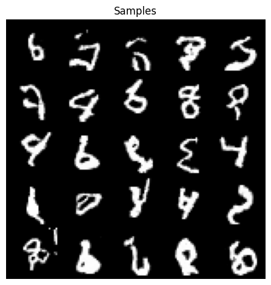

```python
q2c_save_results(q2_c, train_data, test_data)
```

### Expected Results (For Your Reference)

Below are some samples that were generated with correct implementation. We expect you to achieve similar sample quality.

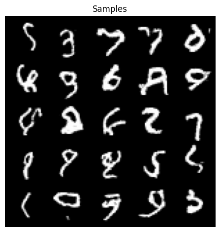

### Inline Question

- In Part 1, you have implemented various PixelCNN models. You have seen the effective receptive fields of each of these models. It's time to visualize them. Please execute the nest cell to visualize receptive fields for PixelCNN and GatedPixelCNN (This cell should run with no issues if you have implemented the MaskedConv2d and GatedConv2d classes correctly, with the given arguments. If you have changed the input arguments etc. you might need to modify this cell.)
- Please briefly explain your observations. What is the difference between the PixelCNN and GatedPixelCNN in terms of these receptive fields? What causes this difference and why is this important?

Your Answers: PixelCNN has a blind spot in the upper-right area that doesn't go away even with more layers. GatedPixelCNN fixes this by splitting into vertical and horizontal stacks with a connection between them, so the receptive field covers almost all previous pixels. This matters because the model can actually use the full context when predicting, which gives better samples.

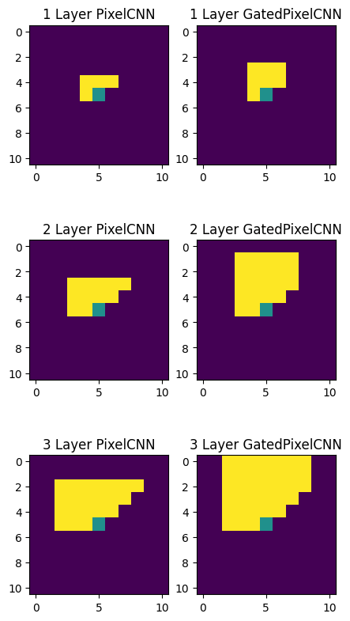

```python
def visualize_receptive_field():
  layer1 = MaskedConv2d('A',1, 1, 3, 1, 1).cuda()
  layer2 = MaskedConv2d('B',1, 1, 3, 1, 1).cuda()
  gated_layer1 = GatedConv2d('A',1, 1, 3, 1).cuda()
  gated_layer2 = GatedConv2d('B',1, 1, 3, 1).cuda()
  x = torch.randn(1, 1, 11, 11).cuda()
  x.requires_grad = True
  x_g = torch.randn(1, 1, 11, 11).cuda()
  x_g.requires_grad = True
  nrows = 3
  fig, ax = plt.subplots(nrows=nrows, ncols=2,figsize=(5,10))
  for j,row in enumerate(ax):
    out_g = torch.cat((x_g, x_g), dim=1)
    out_g = gated_layer1(out_g)
    out = layer1(x)
    for i in range(j):
      out = layer2(out)
      out_g = gated_layer2(out_g)
    out_g = out_g.chunk(2, dim=1)[1]
    col1, col2 = row
    plot_receptive_field(out, x, col1, ' PixelCNN', j+1)
    plot_receptive_field(out_g, x_g, col2, ' GatedPixelCNN', j+1)
    x.grad.zero_()
    x_g.grad.zero_()

visualize_receptive_field()
```

# Part 2: Causal Transformer - iGPT

Now we will move onto the current most popular and widespread autoregressive model, the transformer.

## Part (a) Autoregressive Transformer on Shapes and MNIST

In this part, implement a simple Autoregressive Transformer to model binary MNIST and shapes images (same as Q1, but with a Transformer).

Some additional notes about your transformer implementation:

- iGPT uses learned positional encodings. We recommend to use those here as well. However, you may also use sinusoidal positional encodings if you wish (see the [Attention is All You Need](https://arxiv.org/abs/1706.03762) paper)
- Autoregressive transformer always predicts the **next** token, give prior tokens. iGPT has a special **<bos>** or beginning of sequence token at the start of every sequence every image. Make sure to include this in your implementation as well. You can generate unconditional sample by conditioning with the **<bos>** token.
- While dropout is a common feature in transformer models, you do not need to add it (but may if you wish!).
- Prebuilt transformers exist in some frameworks (i.e. pytorch). Don't just use an off the shelf implementation as the point of the exercise is to better understand the transformer architecture. Building the transformer from the ground up (use primitives such as Linear/Dense layers, LayerNorm, GeLU, Embedding)
- Learning rate warmup and cos learning rate decay are often used when training transformers to improve training stability and improve performance. See if this helps your model! Try 1000 steps of warmup with a cosine learning rate decay.

Paper references

- [Attention Is All You Need](https://arxiv.org/abs/1706.03762)
- [Generative Pretraining from Pixels](https://cdn.openai.com/papers/Generative_Pretraining_from_Pixels_V2.pdf)
- [Language Models are Unsupervised Multitask Learners](https://cdn.openai.com/better-language-models/language_models_are_unsupervised_multitask_learners.pdf)

We recommend the following network design parameters:

- $d_{model}$: 128
- heads: 4
- layers: 2
- GeLU nonlinearities

And the following hyperparameters:

- Batch size: 64 or 32 or 16 (whichever fits in your GPU)
- Learning rate: $10^{-3}$
- 15 epochs or more
- Adam Optimizer (this applies to all Transformers models trained in future parts)

**You will provide these deliverables**

1. Over the course of training, record the average negative log-likelihood (nats / dim) of the training data (per minibatch) and test data (for your entire test set). Code is provided that automatically plots the training curves.
2. Report the final test set performance of your final model
3. 100 samples from the final trained model

```python
from deepul.hw1_helper import *
```

```python
import torch
import torch.nn as nn
import torch.nn.functional as F
from torch import optim
from torch.utils import data
import numpy as np

class CausalSelfAttention(nn.Module):
  def __init__(self, d_model, n_heads, max_len):
    super().__init__()
    assert d_model % n_heads == 0
    self.n_heads = n_heads
    self.head_dim = d_model // n_heads
    self.qkv = nn.Linear(d_model, 3 * d_model)
    self.proj = nn.Linear(d_model, d_model)
    self.register_buffer('mask', torch.tril(torch.ones(max_len, max_len)).unsqueeze(0).unsqueeze(0))

  def forward(self, x):
    B, T, C = x.shape
    qkv = self.qkv(x).reshape(B, T, 3, self.n_heads, self.head_dim).permute(2, 0, 3, 1, 4)
    q, k, v = qkv[0], qkv[1], qkv[2]
    attn = (q @ k.transpose(-2, -1)) / (self.head_dim ** 0.5)
    attn = attn.masked_fill(self.mask[:, :, :T, :T] == 0, float('-inf'))
    attn = F.softmax(attn, dim=-1)
    out = (attn @ v).transpose(1, 2).reshape(B, T, C)
    return self.proj(out)

class TransformerBlock(nn.Module):
  def __init__(self, d_model, n_heads, max_len):
    super().__init__()
    self.ln1 = nn.LayerNorm(d_model)
    self.attn = CausalSelfAttention(d_model, n_heads, max_len)
    self.ln2 = nn.LayerNorm(d_model)
    self.ff = nn.Sequential(
      nn.Linear(d_model, 4 * d_model),
      nn.GELU(),
      nn.Linear(4 * d_model, d_model)
    )

  def forward(self, x):
    x = x + self.attn(self.ln1(x))
    x = x + self.ff(self.ln2(x))
    return x

class AutoregressiveTransformer(nn.Module):
  def __init__(self, vocab_size, d_model, n_heads, n_layers, max_len):
    super().__init__()
    self.vocab_size = vocab_size
    self.bos_token = vocab_size
    self.tok_emb = nn.Embedding(vocab_size + 1, d_model)
    self.pos_emb = nn.Embedding(max_len + 1, d_model)
    self.blocks = nn.Sequential(*[TransformerBlock(d_model, n_heads, max_len + 1) for _ in range(n_layers)])
    self.ln = nn.LayerNorm(d_model)
    self.head = nn.Linear(d_model, vocab_size)

  def forward(self, x):
    B, T = x.shape
    bos = torch.full((B, 1), self.bos_token, dtype=torch.long, device=x.device)
    tokens = torch.cat([bos, x], dim=1)
    tok = self.tok_emb(tokens)
    pos = self.pos_emb(torch.arange(T + 1, device=x.device))
    h = tok + pos
    h = self.blocks(h)
    h = self.ln(h)
    logits = self.head(h[:, :-1, :])
    return logits

def sample_transformer(model, num_samples, seq_len, device):
  model.eval()
  with torch.no_grad():
    tokens = torch.full((num_samples, 1), model.bos_token, dtype=torch.long, device=device)
    for i in range(seq_len):
      tok = model.tok_emb(tokens)
      pos = model.pos_emb(torch.arange(tokens.shape[1], device=device))
      h = tok + pos
      h = model.blocks(h)
      h = model.ln(h)
      logits = model.head(h[:, -1, :])
      probs = F.softmax(logits, dim=-1)
      next_token = torch.multinomial(probs, 1)
      tokens = torch.cat([tokens, next_token], dim=1)
  return tokens[:, 1:]

def q3_a(train_data, test_data, image_shape, dset_id):
  H, W, C = image_shape
  seq_len = H * W * C
  vocab_size = 2
  device = torch.device('cuda' if torch.cuda.is_available() else 'cpu')

  d_model = 128
  n_heads = 4
  n_layers = 2
  batch_size = 64 if seq_len <= 400 else 16
  num_epochs = 15
  lr = 1e-3
  warmup_steps = 1000

  train_flat = torch.from_numpy(train_data.reshape(-1, seq_len)).long()
  test_flat = torch.from_numpy(test_data.reshape(-1, seq_len)).long()
  train_loader = data.DataLoader(data.TensorDataset(train_flat), batch_size=batch_size, shuffle=True)
  test_loader = data.DataLoader(data.TensorDataset(test_flat), batch_size=batch_size, shuffle=False)

  model = AutoregressiveTransformer(vocab_size, d_model, n_heads, n_layers, seq_len).to(device)
  optimizer = optim.Adam(model.parameters(), lr=lr, betas=(0.9, 0.95))

  total_steps = num_epochs * len(train_loader)
  def lr_lambda(step):
    if step < warmup_steps:
      return step / max(1, warmup_steps)
    progress = (step - warmup_steps) / max(1, total_steps - warmup_steps)
    return 0.5 * (1.0 + np.cos(np.pi * progress))
  scheduler = optim.lr_scheduler.LambdaLR(optimizer, lr_lambda)

  train_losses = []
  test_losses = []

  def eval_test():
    model.eval()
    total_loss = 0
    total_tokens = 0
    with torch.no_grad():
      for (batch,) in test_loader:
        batch = batch.to(device)
        logits = model(batch)
        loss = F.cross_entropy(logits.reshape(-1, vocab_size), batch.reshape(-1))
        total_loss += loss.item() * batch.numel()
        total_tokens += batch.numel()
    return total_loss / total_tokens

  test_losses.append(eval_test())
  print(f'init test loss: {test_losses[-1]:.4f}')

  for epoch in range(num_epochs):
    model.train()
    for (batch,) in train_loader:
      batch = batch.to(device)
      logits = model(batch)
      loss = F.cross_entropy(logits.reshape(-1, vocab_size), batch.reshape(-1))
      optimizer.zero_grad()
      loss.backward()
      optimizer.step()
      scheduler.step()
      train_losses.append(loss.item())

    test_losses.append(eval_test())
    print(f'epoch {epoch+1}/{num_epochs}, test loss: {test_losses[-1]:.4f}')

  samples = sample_transformer(model, 100, seq_len, device)
  samples = samples.cpu().numpy().reshape(100, H, W, C).astype(np.uint8)
  return np.array(train_losses), np.array(test_losses), samples
```

### Results

Once you've implemented `q3_a`, execute the cells below to visualize and save your results

```
init test loss: 1.0049
epoch 1/15, test loss: 0.1727
epoch 2/15, test loss: 0.0899
epoch 3/15, test loss: 0.0763
epoch 4/15, test loss: 0.0700
epoch 5/15, test loss: 0.0591
epoch 6/15, test loss: 0.0532
epoch 7/15, test loss: 0.0489
epoch 8/15, test loss: 0.0458
epoch 9/15, test loss: 0.0447
epoch 10/15, test loss: 0.0419
epoch 11/15, test loss: 0.0409
epoch 12/15, test loss: 0.0397
epoch 13/15, test loss: 0.0387
epoch 14/15, test loss: 0.0382
epoch 15/15, test loss: 0.0381
Final Test Loss: 0.0381
```

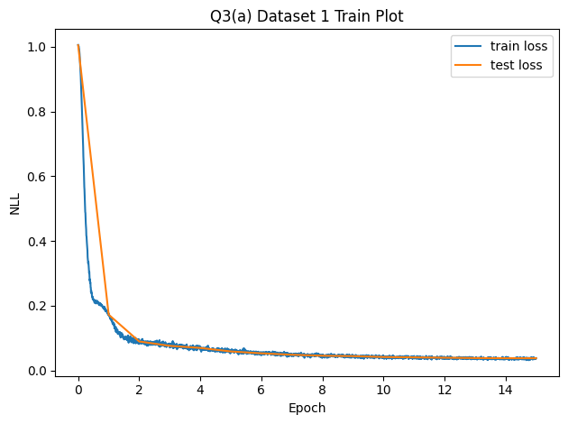

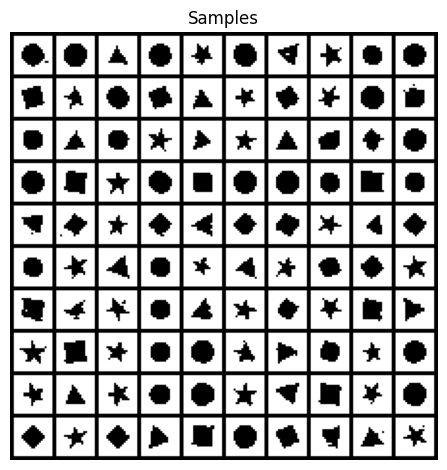

```python
q3ab_save_results(1, 'a', q3_a)
```

```
init test loss: 1.2227
epoch 1/15, test loss: 0.0941
epoch 2/15, test loss: 0.0874
epoch 3/15, test loss: 0.0840
epoch 4/15, test loss: 0.0823
epoch 5/15, test loss: 0.0804
epoch 6/15, test loss: 0.0795
epoch 7/15, test loss: 0.0786
epoch 8/15, test loss: 0.0780
epoch 9/15, test loss: 0.0774
epoch 10/15, test loss: 0.0769
epoch 11/15, test loss: 0.0766
epoch 12/15, test loss: 0.0762
epoch 13/15, test loss: 0.0760
epoch 14/15, test loss: 0.0760
epoch 15/15, test loss: 0.0760
Final Test Loss: 0.0760
```

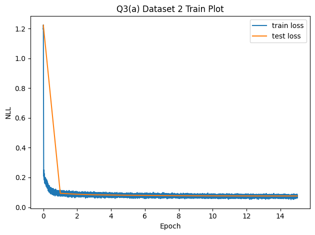

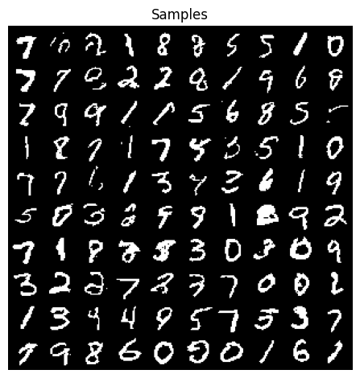

```python
q3ab_save_results(2, 'a', q3_a)
```

### Inline Question

- Please explain briefly what is the motivation behind iGPT (1-2 sentences), how it is training objective works (2-3 sentences)? How can we check the performance of this unsupervised model (2-3 sentences)?

Your Answers: iGPT treats images as sequences of pixels and models them with a transformer, showing that the same autoregressive approach used in NLP works for images too. It trains by predicting the next pixel given all previous pixels, minimizing cross-entropy loss over the flattened image sequence. We can evaluate it by looking at the test loss (lower means better density estimation) and by checking if the generated samples look realistic and diverse.

## Part (b) iGPT on Colored Shapes and MNIST

Now, implement an iGPT that models color. In order to reduce the length of token sequences, iGPT models each RGB pixel as a **single** token. This effectively reduces the context length from H*W*C to just H*W. iGPT does this through a k-means clustering approach. Because our images only each can only take on 4 values (2 bits) per channel, we can represent each pixel with 64 values (6 bits). Convert the dataset into an image of tokens and train iGPT on the colored shapes and MNIST dataset.

Checkout the iGPT paper for more details: [Generative Pretraining from Pixels](https://cdn.openai.com/papers/Generative_Pretraining_from_Pixels_V2.pdf)

Training times and hyperparameter settings should be the same as part (a), except train for longer (15 epochs)

**You will provide these deliverables**

1. Over the course of training, record the average negative log-likelihood (nats / dim) of the training data (per minibatch) and test data (for your entire test set). Code is provided that automatically plots the training curves.
2. Report the final test set performance of your final model
3. 100 samples from the final trained model

```python
def q3_b(train_data, test_data, image_shape, dset_id):
  H, W, C = image_shape
  seq_len = H * W
  vocab_size = 64  # 4^3
  device = torch.device('cuda' if torch.cuda.is_available() else 'cpu')

  d_model = 128
  n_heads = 4
  n_layers = 2
  batch_size = 64 if seq_len <= 400 else 16
  num_epochs = 15
  lr = 1e-3
  warmup_steps = 1000

  # rgb -> single token
  def encode(imgs):
    return imgs[:, :, :, 0] * 16 + imgs[:, :, :, 1] * 4 + imgs[:, :, :, 2]

  def decode(tokens):
    r = tokens // 16
    g = (tokens % 16) // 4
    b = tokens % 4
    return np.stack([r, g, b], axis=-1)

  train_flat = torch.from_numpy(encode(train_data).reshape(-1, seq_len)).long()
  test_flat = torch.from_numpy(encode(test_data).reshape(-1, seq_len)).long()
  train_loader = data.DataLoader(data.TensorDataset(train_flat), batch_size=batch_size, shuffle=True)
  test_loader = data.DataLoader(data.TensorDataset(test_flat), batch_size=batch_size, shuffle=False)

  model = AutoregressiveTransformer(vocab_size, d_model, n_heads, n_layers, seq_len).to(device)
  optimizer = optim.Adam(model.parameters(), lr=lr, betas=(0.9, 0.95))

  total_steps = num_epochs * len(train_loader)
  def lr_lambda(step):
    if step < warmup_steps:
      return step / max(1, warmup_steps)
    progress = (step - warmup_steps) / max(1, total_steps - warmup_steps)
    return 0.5 * (1.0 + np.cos(np.pi * progress))
  scheduler = optim.lr_scheduler.LambdaLR(optimizer, lr_lambda)

  train_losses = []
  test_losses = []

  def eval_test():
    model.eval()
    total_loss = 0
    total_tokens = 0
    with torch.no_grad():
      for (batch,) in test_loader:
        batch = batch.to(device)
        logits = model(batch)
        loss = F.cross_entropy(logits.reshape(-1, vocab_size), batch.reshape(-1))
        total_loss += loss.item() * batch.numel()
        total_tokens += batch.numel()
    return total_loss / total_tokens

  test_losses.append(eval_test())
  print(f'init test loss: {test_losses[-1]:.4f}')

  for epoch in range(num_epochs):
    model.train()
    for (batch,) in train_loader:
      batch = batch.to(device)
      logits = model(batch)
      loss = F.cross_entropy(logits.reshape(-1, vocab_size), batch.reshape(-1))
      optimizer.zero_grad()
      loss.backward()
      optimizer.step()
      scheduler.step()
      train_losses.append(loss.item())

    test_losses.append(eval_test())
    print(f'epoch {epoch+1}/{num_epochs}, test loss: {test_losses[-1]:.4f}')

  samples = sample_transformer(model, 100, seq_len, device)
  samples = samples.cpu().numpy().reshape(100, H, W)
  samples = decode(samples).astype(np.uint8)
  return np.array(train_losses), np.array(test_losses), samples
```

### Results

Once you've implemented `q2_b`, execute the cells below to visualize and save your results

```
init test loss: 4.3012
epoch 1/15, test loss: 1.3555
epoch 2/15, test loss: 0.1764
epoch 3/15, test loss: 0.1147
epoch 4/15, test loss: 0.1028
epoch 5/15, test loss: 0.0910
epoch 6/15, test loss: 0.0831
epoch 7/15, test loss: 0.0764
epoch 8/15, test loss: 0.0706
epoch 9/15, test loss: 0.0672
epoch 10/15, test loss: 0.0639
epoch 11/15, test loss: 0.0613
epoch 12/15, test loss: 0.0599
epoch 13/15, test loss: 0.0588
epoch 14/15, test loss: 0.0584
epoch 15/15, test loss: 0.0583
Final Test Loss: 0.0583
```

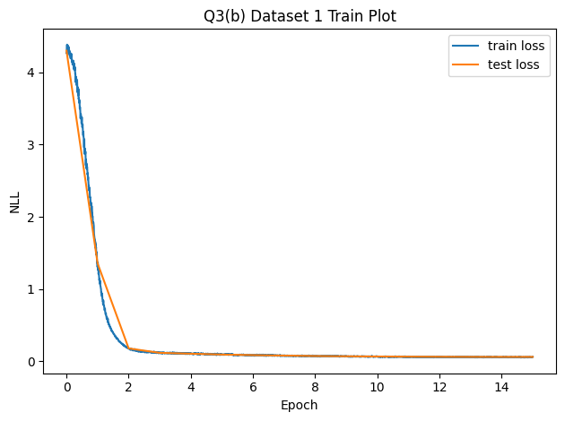

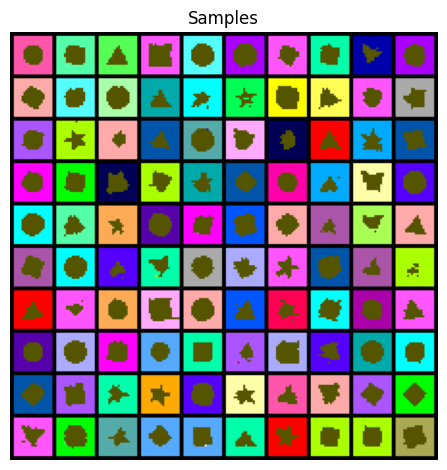

```python
q3ab_save_results(1, 'b', q3_b)
```

```
init test loss: 4.2219
epoch 1/15, test loss: 0.3645
epoch 2/15, test loss: 0.2311
epoch 3/15, test loss: 0.1793
epoch 4/15, test loss: 0.1568
epoch 5/15, test loss: 0.1401
epoch 6/15, test loss: 0.1292
epoch 7/15, test loss: 0.1204
epoch 8/15, test loss: 0.1154
epoch 9/15, test loss: 0.1092
epoch 10/15, test loss: 0.1056
epoch 11/15, test loss: 0.1016
epoch 12/15, test loss: 0.0988
epoch 13/15, test loss: 0.0974
epoch 14/15, test loss: 0.0965
epoch 15/15, test loss: 0.0963
Final Test Loss: 0.0963
```

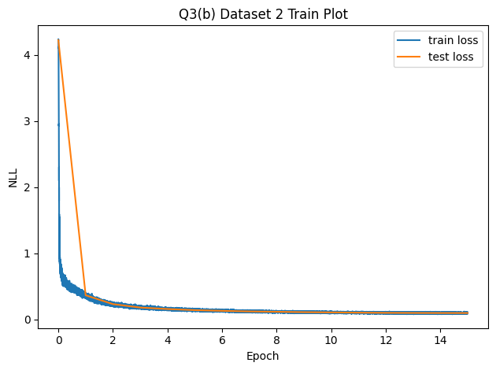

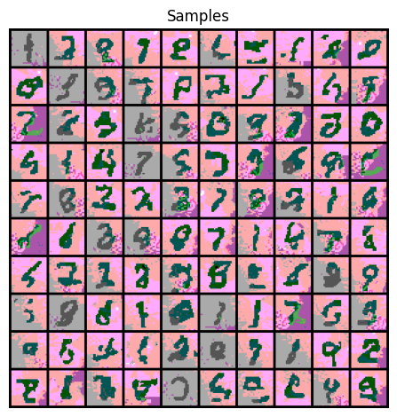

```python
q3ab_save_results(2, 'b', q3_b)
```

### Inline Question

- How might including colored shapes alongside the MNIST dataset in the training of iGPT affect the model's ability to generalize and learn representations, and what is the underlying intuition for this effect (explain in 2-3 sentences)?

Your Answers: Training on both colored shapes and MNIST gives the model more variety in structure and color, which helps it learn more general features instead of overfitting to one type of data. The shapes teach simple spatial patterns and color combinations, while MNIST adds more complex structure. This diversity acts like a form of data augmentation and can improve generalization.

# [20 points] Bonus: PixelCNN Super-Resolution

As a bonus, you will **reuse the Gated PixelCNN model from Part 1** and adapt it to a conditional setting in order to perform super-resolution. You will follow the method introduced in the paper [Pixel Recursive Super Resolution](https://openaccess.thecvf.com/content_ICCV_2017/papers/Dahl_Pixel_Recursive_Super_ICCV_2017_paper.pdf).

**Intuition**: the low-res image provides coarse structure, while the autoregressive model fills in fine details.

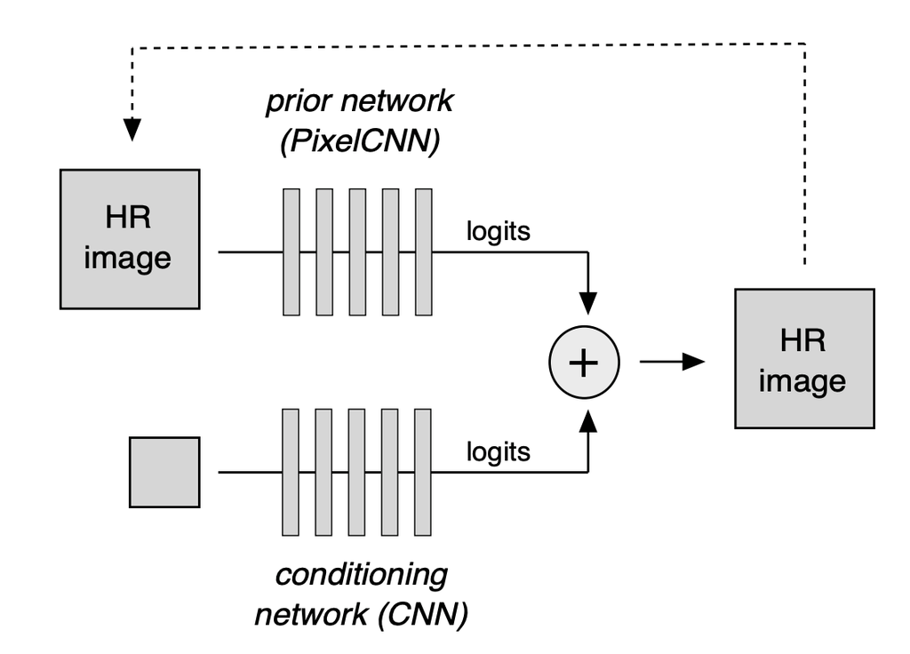

### Your Solution

In this bonus task, the objective is to generate a high-resolution MNIST image (`28×28`) given a corresponding low-resolution version (`7×7`).

You are expected to implement a conditional autoregressive super-resolution model from scratch. We will not provide step-by-step implementation guidance. Instead, you should rely on the concepts discussed in the paper and integrate them into your existing framework.

Specifically, you should use your previously implemented Gated PixelCNN as the autoregressive (PixelCNN) component of the model. The conditioning mechanism should be designed and integrated by you, following the principles described in the paper.

Importantly, we are **not** concerned with achieving state-of-the-art visual sample quality. The goal of this bonus task is to demonstrate correct architectural implementation and conditioning behavior. Outputs that are structurally consistent and reasonably plausible will be considered sufficient.

```python
class ConditionalGatedPixelCNN(nn.Module):
  def __init__(self, num_layers=5, num_channels=64, kernel_size=7):
    super().__init__()
    padding = kernel_size // 2
    self.initial_conv = MaskedConv2d('A', 1, num_channels, kernel_size, 1, padding)
    self.initial_bn = nn.BatchNorm2d(2 * num_channels)
    self.gated_layers = nn.ModuleList()
    self.bns = nn.ModuleList()
    for _ in range(num_layers - 2):
      self.gated_layers.append(GatedConv2d('B', num_channels, num_channels, kernel_size, padding))
      self.bns.append(nn.BatchNorm2d(2 * num_channels))
    self.final_conv = MaskedConv2d('B', num_channels, 256, kernel_size, 1, padding)
    self.cond_net = nn.Sequential(
      nn.Upsample(size=(28, 28), mode='bilinear', align_corners=False),
      nn.Conv2d(1, num_channels, kernel_size=3, padding=1),
      nn.ReLU(),
      nn.Conv2d(num_channels, 2 * num_channels, kernel_size=1)
    )

  def forward(self, x, cond):
    cond_features = self.cond_net(cond)
    x = self.initial_conv(x)
    x = torch.cat([x, x], dim=1)
    x = F.relu(self.initial_bn(x + cond_features))
    for gated, bn in zip(self.gated_layers, self.bns):
      x = gated(x)
      x = F.relu(bn(x + cond_features))
    x = x.chunk(2, dim=1)[1]
    x = self.final_conv(x)
    return x

def downsample(images, factor=4):
  return F.avg_pool2d(images, kernel_size=factor, stride=factor)

def sample_sr(model, low_res, device):
  model.eval()
  B = low_res.shape[0]
  sample = torch.zeros(B, 1, 28, 28, device=device)
  with torch.no_grad():
    for i in range(28):
      for j in range(28):
        out = model(sample, low_res)
        probs = F.softmax(out[:, :, i, j], dim=-1)
        sample[:, :, i, j] = torch.multinomial(probs, 1).float() / 255.0
  return sample

device = torch.device('cuda' if torch.cuda.is_available() else 'cpu')
sr_model = ConditionalGatedPixelCNN().to(device)
optimizer = optim.Adam(sr_model.parameters(), lr=1e-3)
criterion = nn.CrossEntropyLoss()
train_loader_sr = data.DataLoader(train_data, batch_size=64, shuffle=True)
num_epochs_sr = 3

for epoch in range(num_epochs_sr):
  sr_model.train()
  epoch_loss = 0
  count = 0
  for images, _ in train_loader_sr:
    images = images.to(device)
    low_res = downsample(images)
    targets = (images[:, 0] * 255).long()
    output = sr_model(images, low_res)
    loss = criterion(output, targets)
    optimizer.zero_grad()
    loss.backward()
    optimizer.step()
    epoch_loss += loss.item()
    count += 1
  print(f'epoch {epoch+1}/{num_epochs_sr}, loss: {epoch_loss/count:.4f}')
```

```
epoch 1/3, loss: 0.8249
epoch 2/3, loss: 0.7263
epoch 3/3, loss: 0.7050
```

### Visualization

You may use the following function to visualize your samples after training.

```python
def visualize_sampes(original_hr, low_res, generated_samples, num_samples=4):
    plt.figure(figsize=(16, 12))
    for i in range(min(num_samples, len(original_hr))):
        orig = original_hr[i:i+1]
        lowres = low_res[i:i+1]
        generated = generated_samples[i, 0].cpu().numpy()

        h, w = orig.shape[-2:]
        lowres_nearest = F.interpolate(lowres, size=(h, w), mode='nearest')[0, 0].cpu().numpy()
        lowres_bicubic = F.interpolate(lowres, size=(h, w), mode='bicubic', align_corners=False)[0, 0].cpu().numpy()
        orig = orig[0, 0].cpu().numpy()

        plt.subplot(4, num_samples, i + 1)
        plt.imshow(orig, cmap='gray', vmin=0, vmax=1)
        plt.title('Original HR')
        plt.axis('off')

        plt.subplot(4, num_samples, i + 1 + num_samples)
        plt.imshow(lowres_nearest, cmap='gray', vmin=0, vmax=1)
        plt.title('Low-Res (Nearest)')
        plt.axis('off')

        plt.subplot(4, num_samples, i + 1 + 2*num_samples)
        plt.imshow(lowres_bicubic, cmap='gray', vmin=0, vmax=1)
        plt.title('Bicubic Upsampling')
        plt.axis('off')

        plt.subplot(4, num_samples, i + 1 + 3*num_samples)
        plt.imshow(generated, cmap='gray', vmin=0, vmax=1)
        plt.title('Generated')
        plt.axis('off')

    plt.tight_layout()
    plt.show()
```

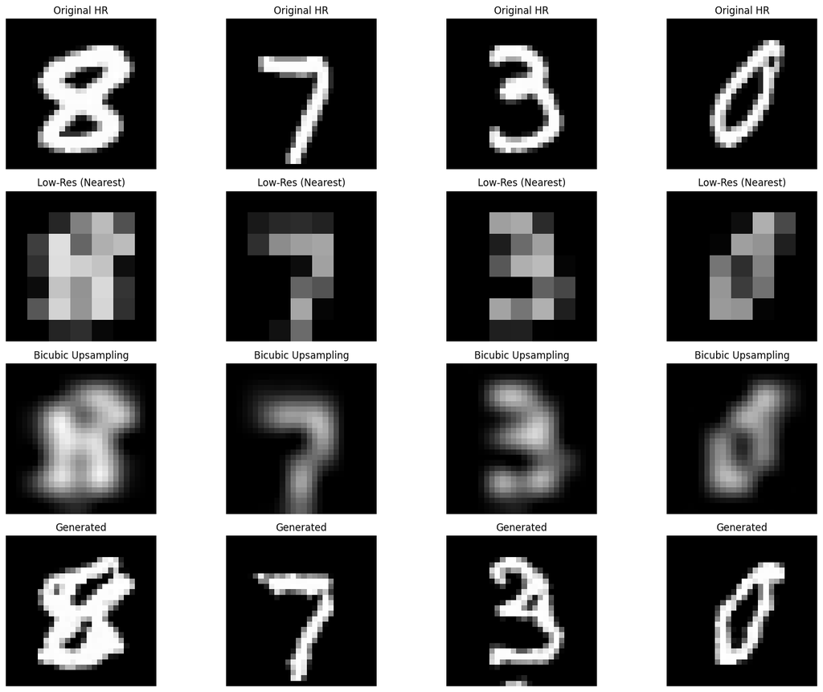

```python
sr_model.eval()
test_loader_sr = data.DataLoader(test_data, batch_size=4, shuffle=True)
test_images, _ = next(iter(test_loader_sr))
test_images = test_images.to(device)
low_res_images = downsample(test_images)
generated = sample_sr(sr_model, low_res_images, device)
visualize_sampes(test_images.cpu(), low_res_images.cpu(), generated.cpu(), num_samples=4)
```